# Gustavo Diaz – tulane

## Balancing Precision and Retention in Experimental Design

Forthcoming in *Political Analysis*

**Gustavo Diaz**  
Northwestern University  
gustavo.diaz@northwestern.edu  
gustavodiaz.org

**Erin Rossiter**  
University of Notre Dame  
erossite@nd.edu  
[erossiter.com](https://erossiter.com/)

Paper and slides: [gustavodiaz.org/tulane](https://gustavodiaz.org/tulane.html)

[figure not shown]

## A survey experiment

- N = 1,000
- **Vignette:** Incumbent politician seeking reelection
- **Manipulation:** Clean (control); corrupt (treatment)
- **Outcome:** Would you vote to reelect? (0: no, 1: yes)

**Standard design**

- Treatments assigned by simple/complete randomization
- Outcome measured once after tretment

## A survey experiment

- N = 1,000
- **Vignette:** Incumbent politician seeking reelection
- **Manipulation:** Clean (control); corrupt (treatment)
- **Outcome:** Would you vote to reelect? (0: no, 1: yes)

| Vignette | Vote | p.value |
| --- | --- | --- |
| Clean | 0.510 |  |
| Corrupt | 0.448 |  |
| Difference | -0.062 | 0.04979 |

## A survey experiment

| Vignette | Vote | p.value |
| --- | --- | --- |
| Clean | 0.510 |  |
| Corrupt | 0.448 |  |
| Difference | -0.062 | 0.04979 |

What is the problem?

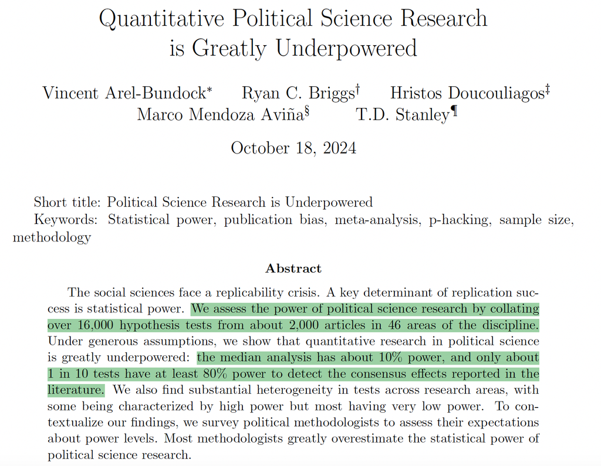

## A survey experiment

| Vignette | Vote | p.value |
| --- | --- | --- |
| Clean | 0.510 |  |
| Corrupt | 0.448 |  |
| Difference | -0.062 | 0.04979 |

What is the problem?  
*Low statistical precision*

What could we have done differently?

## Research design

[figure not shown]

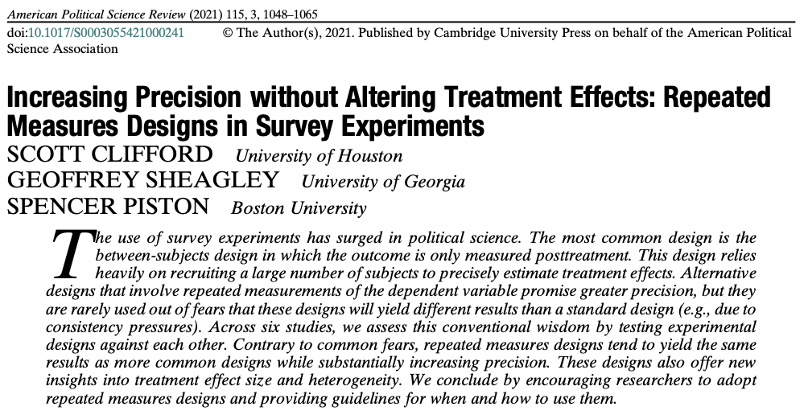

## Research design

**Alternative designs**

A deviation from the **standard** design aimed at **improving statistical precision**

**Puzzle:** Often recommended, rarely implemented

**Argument:** Scholars wary of hidden costs (*sample loss*)

**Goal:** Show that benefits outweigh costs

**Takeaway:** Alternative designs increase precision even when incurring sample loss

# Outline

1. Theory: Statistical precision, sample loss, alternative designs
2. Replication study: Precision gains withstand sample loss
3. Conclusion: More diversity in research design
4. Related work

# Outline

1. **Theory: Statistical precision, sample loss, alternative designs**
2. Replication study: Precision gains withstand sample loss
3. Conclusion: More diversity in research design
4. Related work

## Standard experiment

**Notation**

- $Z_i = \{0,1\}$ condition (0: control, 1: treatment)
- $Y_i(Z_i)$ is the individual **potential outcome**

Observed outcome

$$Y_i = \begin{cases}
Y_i(0) & : & Z_i = 0 \\
Y_i(1) & : & Z_i = 1
\end{cases}$$

## Standard experiment

**Estimator**

Difference-in-means

$$\widehat{ATE} = E[Y_i(1) | Z_i = 1] - E[Y_i(0) | Z_i = 0]$$

```r
# Difference-in-means
t.test(vote ~ vignette, data = experiment)

# Regression equivalent
lm(vote ~ vignette, data = experiment)
```

## Standard experiment

**Estimator**

Standard error of $\widehat{ATE}$

$$SE(\widehat{ATE}) = \sqrt{\frac{\text{Var}(Y_i(0)) + \text{Var}(Y_i(1)) + 2\text{Cov}(Y_i(0), Y_i(1))}{N-1}}$$

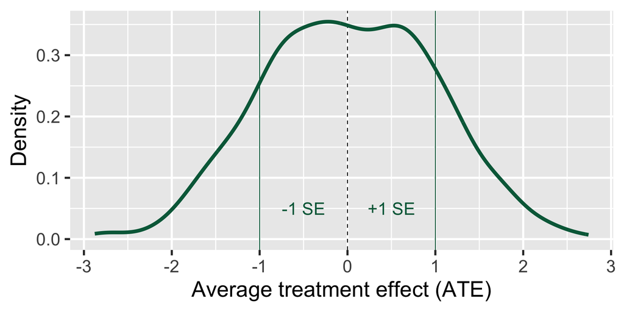

## Standard experiment

**Estimator**

Standard error of $\widehat{ATE}$

$$SE(\widehat{ATE}) = \sqrt{\frac{\text{Var}(Y_i(0)) + \text{Var}(Y_i(1)) + 2\text{Cov}(Y_i(0), Y_i(1))}{N-1}}$$

## Standard experiment

**Estimator**

Standard error of $\widehat{ATE}$

$$SE(\widehat{ATE}) = \sqrt{\frac{\color{#006747}{\text{Var}(Y_i(0)) + \text{Var}(Y_i(1)) + 2\text{Cov}(Y_i(0), Y_i(1))}}{\color{#4E2A84}{N-1}}}$$

**Variance component**

- Make smaller with alternative designs
- Needs access to pre-treatment variables that correlate with (potential) outcomes

## Standard experiment

**Estimator**

Standard error of $\widehat{ATE}$

$$SE(\widehat{ATE}) = \sqrt{\frac{\color{#006747}{\text{Var}(Y_i(0)) + \text{Var}(Y_i(1)) + 2\text{Cov}(Y_i(0), Y_i(1))}}{\color{#4E2A84}{N-1}}}$$

**Sample size component**

- Quadruple $N$ to halve $SE(\widehat{ATE})$
- Cost-prohibitive in many applications

## Standard experiment

**Estimator**

Standard error of $\widehat{ATE}$

$$SE(\widehat{ATE}) = \sqrt{\frac{\color{#006747}{\text{Var}(Y_i(0)) + \text{Var}(Y_i(1)) + 2\text{Cov}(Y_i(0), Y_i(1))}}{\color{#4E2A84}{N-1}}}$$

**Hidden cost**

Trying to decrease **variance component** may lead to **sample loss**

**Concern:** Offset statistical precision gains

## Sample loss

**Explicit**

Sample loss introduced as a *consequence* of implementing an alternative design

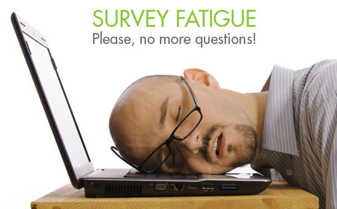

## Sample loss

**Implicit**

Sample loss *internalized by the researcher* before implementing an alternative design

## Sample loss

**Implicit**

Sample loss *internalized by the researcher* before implementing an alternative design

## Sample loss

**Implicit**

Sample loss *internalized by the researcher* before implementing an alternative design

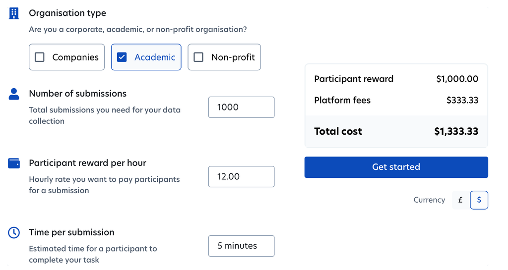

## Sample loss

**Implicit**

Sample loss *internalized by the researcher* before implementing an alternative design

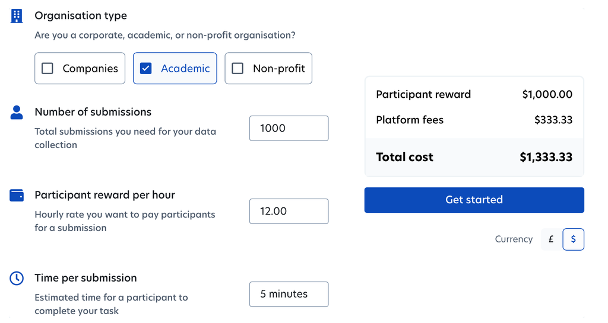

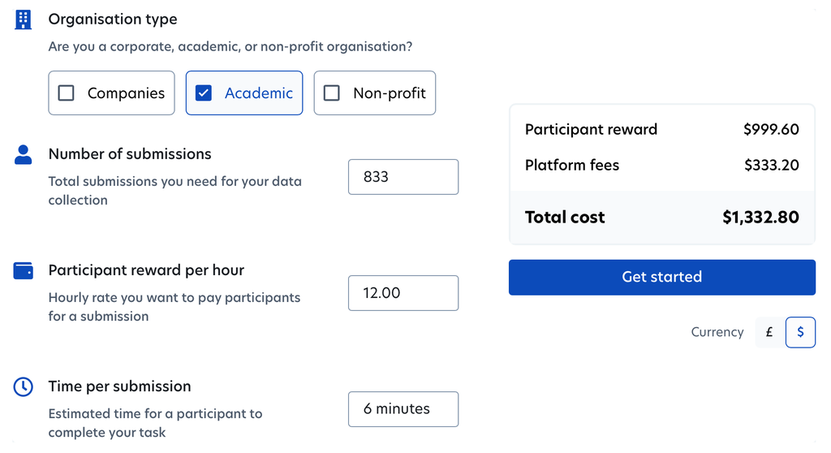

## Sample loss

**Implicit**

Sample loss *internalized by the researcher* before implementing an alternative design

**Fixed budget**

5 minutes 6 minutes

N = 1,000 N = 833

prolific.com/calculator

## Example: Pre-post design

| Design | Pre-treatment | Treatment | Post-treatment |
| --- | --- | --- | --- |
| Standard |  | $Z_i$ | $Y_i$ |
| Pre-post | $Y_{i, t=1}$ | $Z_i$ | $Y_{i, t=2}$ |

## Example: Pre-post design

| Design | Pre-treatment | Treatment | Post-treatment |
| --- | --- | --- | --- |
| Standard |  | $Z_i$ | $Y_i$ |
| Pre-post | $Y_{i, t=1}$ | $Z_i$ | $Y_{i, t=2}$ |

## Example: Pre-post design

| Design | Pre-treatment | Treatment | Post-treatment |
| --- | --- | --- | --- |
| Standard |  | $Z_i$ | $Y_i$ |
| Pre-post | $Y_{i, t=1}$ | $Z_i$ | $Y_{i, t=2}$ |

$$\widehat{ATE}_{\text{Standard}} = E[Y_i(1) | Z_i = 1] - E[Y_i(0) | Z_i = 0]$$

$$\begin{align}
\widehat{ATE}_{\text{Pre-post}} = & E[(Y_{i,t=2}(1) - Y_{i,t=1}) | Z_i = 1] - \\
& E[(Y_{i,t=2}(0) - Y_{i,t=1}) | Z_i = 0]
\end{align}$$

## Example: Pre-post design

| Design | Pre-treatment | Treatment | Post-treatment |
| --- | --- | --- | --- |
| Standard |  | $Z_i$ | $Y_i$ |
| Pre-post | $Y_{i, t=1}$ | $Z_i$ | $Y_{i, t=2}$ |

$$\widehat{ATE}_{\text{Standard}} = E[Y_i(1) | Z_i = 1] - E[Y_i(0) | Z_i = 0]$$

$$\begin{align}
\widehat{ATE}_{\text{Pre-post}} = & E[(Y_{i,t=2}(1) \color{#006747}{- Y_{i,t=1}}) | Z_i = 1] - \\
& E[(Y_{i,t=2}(0) \color{#006747}{- Y_{i,t=1}}) | Z_i = 0]
\end{align}$$

## Example: Pre-post design

| Design | Pre-treatment | Treatment | Post-treatment |
| --- | --- | --- | --- |
| Standard |  | $Z_i$ | $Y_i$ |
| Pre-post | $Y_{i, t=1}$ | $Z_i$ | $Y_{i, t=2}$ |

```r
# Standard design
lm(vote ~ vignette, data = experiment)

# Pre-post
lm(vote_post ~ vignette + vote_pre, data = experiment)
```

## What does this do?

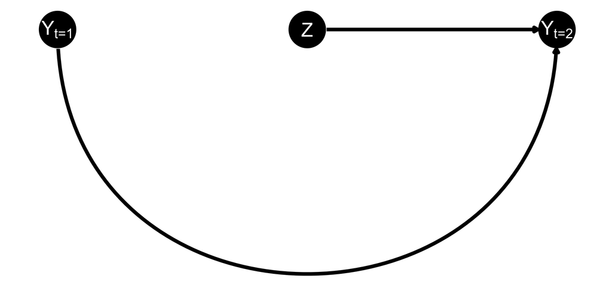

# Outline

1. **Theory: Statistical precision, sample loss, alternative designs**
2. Replication study: Precision gains withstand sample loss
3. Conclusion: More diversity in research design
4. Related work

# Outline

1. Theory: Statistical precision, sample loss, alternative designs
2. **Replication study: Precision gains withstand sample loss**
3. Conclusion: More diversity in research design
4. Related work

## Replication study

|  | [Dietrich and Hayes (2023 JOP)](https://doi.org/10.1086/723966) | [Bayram and Graham (2022 JOP)](https://doi.org/10.1086/719414) | [Tappin and Hewitt (2023 JEPS)](https://doi.org/10.1017/XPS.2021.22) |
| --- | --- | --- | --- |
| Study | 1 (DH) | 2 (BG) | 3 (TH) |
| Subfield | AP | IR | AP |
| Topic | Race and issue-based symbolism | Support for IO foreign aid | Party cues and policy opinions |
| Arms | 8 | 5 | 2 |
| Obs. | 515 | 1000 | 775 |
| Waves | 1 | 1 | 2 |
| Concern | Hard to reach population | More precision | Effect persistence |

## Replication study

|  | [Dietrich and Hayes (2023 JOP)](https://doi.org/10.1086/723966) | [Bayram and Graham (2022 JOP)](https://doi.org/10.1086/719414) | [Tappin and Hewitt (2023 JEPS)](https://doi.org/10.1017/XPS.2021.22) |
| --- | --- | --- | --- |
| Study | 1 (DH) | 2 (BG) | 3 (TH) |
| Subfield | AP | IR | AP |
| Topic | Race and issue-based symbolism | Support for IO foreign aid | Party cues and policy opinions |
| Arms | 8 | 5 | 2 |
| Obs. | 515 | 1000 | 775 |
| Waves | 1 | 1 | 2 |
| Concern | Hard to reach population | More precision | Effect persistence |

## Replication design

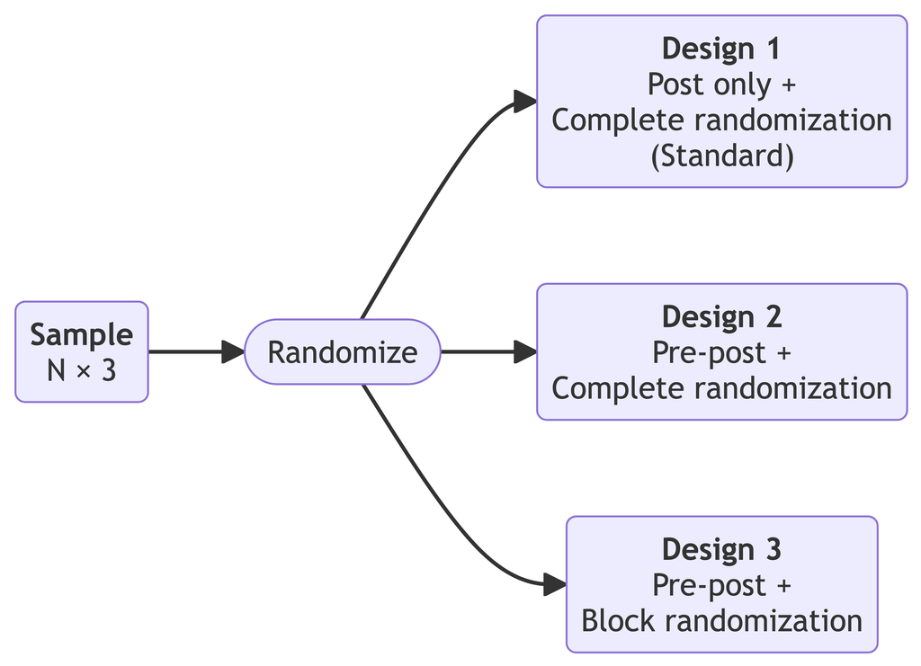

## Replication design

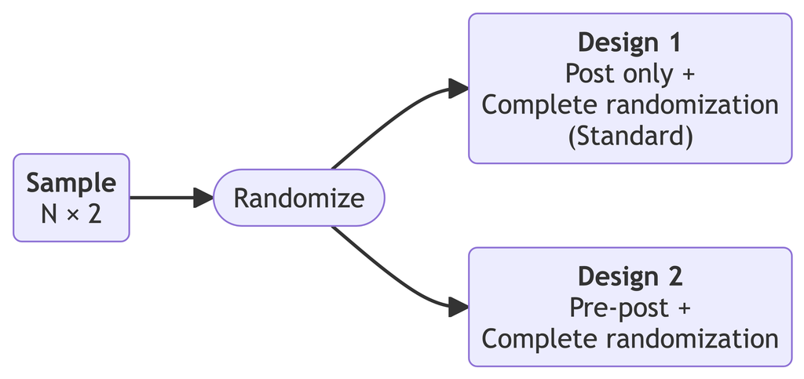

- N = 2,018
- 50% longer survey
- Focus on *earmarking cost* treatment (vs. control)

**Principle:** Stack *against* alternative designs

**Goal:** Evaluate explicit/implicit sample loss

## Explicit sample loss

[figure not shown]

## Explicit sample loss

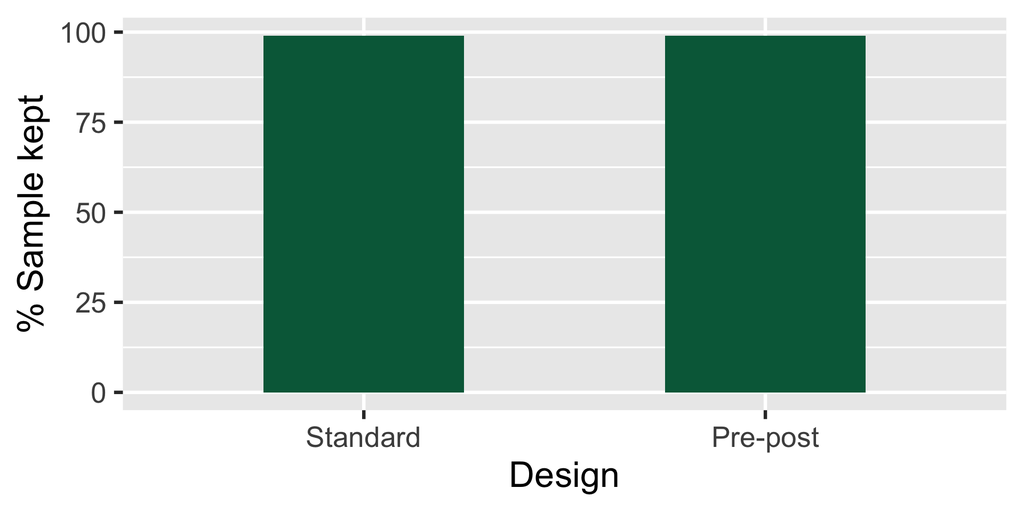

## Also

**No evidence of…**

- Different treatment effects
- Differential sample composition
- Differential post-treatment attrition

## Implicit sample loss

**Simulation**

- Start with original sample size
- Randomly omit observations *in alternative design only* (0-50%)
- Re-estimate treatment effects and record standard errors
- Calculate % change in standard errors $\frac{(\text{Alternative} - \text{Standard})}{\text{Standard}}$
- Repeat 1,000 times per sample size

## Implicit sample loss

[figure not shown]

## Implicit sample loss

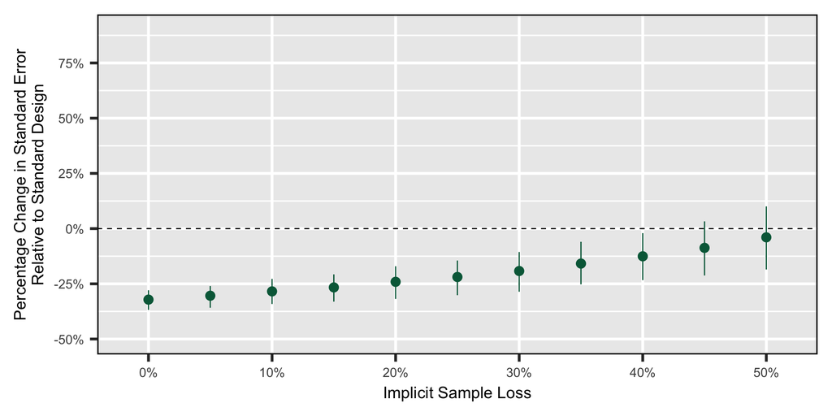

# Outline

1. Theory: Statistical precision, sample loss, alternative designs
2. **Replication study: Precision gains withstand sample loss**
3. Conclusion: More diversity in research design
4. Related work

# Outline

1. Theory: Statistical precision, sample loss, alternative designs
2. Replication study: Precision gains withstand sample loss
3. **Conclusion: More diversity in research design**
4. **Related work**

## Summary

- **Puzzle:** Alternative designs rare
- **Argument:** Concerns about explicit/implicit sample loss offsetting precision gains
- **Findings:** Alternative designs withstand sample loss
- **Contribution:** Tools to navigate research design tradeoffs *before* data collection
- **Wrinkle:** Alternative designs require extensive piloting

## Also in the paper

1. More replications
2. Simulated replications
3. Balancing precision, retention, *and bias*
4. Guidelines for pre-analysis stage

## Research program

1. Develop standards to navigate research design tradeoffs *(this project)*
2. Create *tools* to inform research design choices

[figure not shown]

doi.org/10.1017/XPS.2023.24

## Research program

1. Develop standards to navigate research design tradeoffs *(this project)*
2. Create *tools* to inform research design choices
3. Inform applications in CP and political behavior

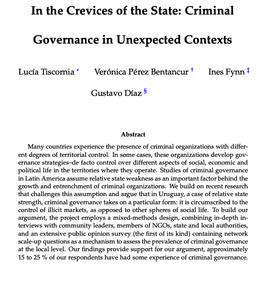

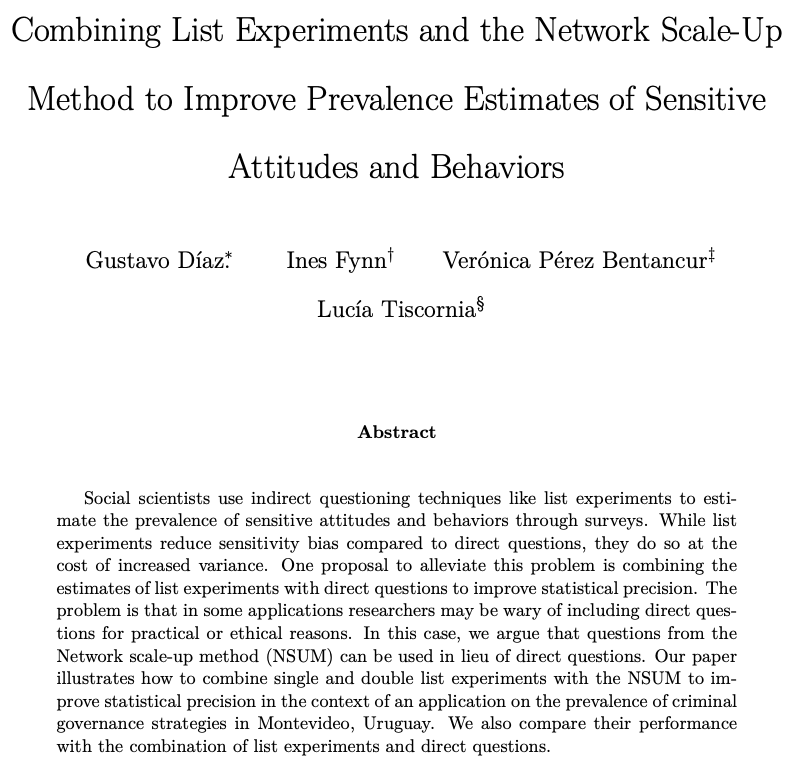

[gustavodiaz.org/research](https://gustavodiaz.org/research.html)

# Thank you!

**Paper and slides:** [gustavodiaz.org/tulane](https://gustavodiaz.org/tulane.html)

[figure not shown]